# Απομόνωση Πραγματικών Ριζών

439 Υπολογιστική Άλγεβρα — Κεφάλαιο 4

Ζαφειράκης Ζαφειρακόπουλος

2026-09-03

## Ατζέντα

- Φράγματα ριζών
- Κανόνας προσήμων του Descartes
- Θεώρημα Budan και διχοτόμηση
- Ακολουθίες Sturm
- Απομόνωση με συνεχή κλάσματα
- Φράγμα διαχωρισμού και πολυπλοκότητα

# Φράγματα ριζών

## Πάνω φράγματα

Για $f=x^d+c_{d-1}x^{d-1}+\cdots+c_0$ **μονικό**, $f(a)=0$:

- **Cauchy:** $|a| < 1+\max_i |c_i|$
- **Zassenhaus:** $|a| \le 2\max_i |c_i|^{1/(d-i)}$
- **Landau:** $|a| \le (c_0^2+\cdots+c_{d-1}^2)^{1/2}$

$6$

# Κανόνας προσήμων του Descartes

## Θεώρημα (Descartes)

Ο αριθμός των **θετικών** ριζών ενός $f$ (με πολλαπλότητα) ισούται με τις εναλλαγές προσήμου στους συντελεστές, ή διαφέρει κατά **άρτιο**.

Αρνητικές ρίζες: εφαρμόζουμε το ίδιο στο $f(-x)$.

## Παράδειγμα

```
3
```

# Θεώρημα Budan και διχοτόμηση

## Θεώρημα (Budan)

Για $\rho<r$, $V_\rho,V_r$ = εναλλαγές προσήμου των $f(x+\rho)$, $f(x+r)$:

1. $V_\rho \ge V_r$
2. πλήθος ριζών στο $(\rho,r) \le V_\rho - V_r$
3. αν γνησίως μικρότερο, η διαφορά είναι **άρτια**

## Αλγόριθμος διχοτόμησης

Ξεκινώντας από $[-C,C]$ (φράγμα Cauchy), για κάθε $(\rho,r)$:

- $V_\rho-V_r=0$: καμία ρίζα, πετάμε
- $V_\rho-V_r=1$: **απομονώνει** μία ρίζα
- $V_\rho-V_r>1$: χωρίζουμε στη μέση

**Προειδοποίηση**

Το φράγμα Budan μπορεί να **υπερεκτιμά** κατά άρτιο αριθμό. Οι ακολουθίες Sturm λύνουν αυτό.

# Ακολουθίες Sturm

## Ορισμός

$(f_1,\dots,f_k)$ είναι **ακολουθία Sturm** για το $f$ στο $[a,b]$ αν $f_1=f$ και:

1. $f_1(a)f_1(b)\neq 0$
2. $f_k(c)\neq 0$ σε όλο το $[a,b]$
3. $f_j(c)=0 \implies f_{j-1}(c)f_{j+1}(c)<0$
4. $f_1(c)=0 \implies$ το $f_1f_2$ αλλάζει πρόσημο $-\to+$

Κατασκευή (square-free $f$): $f_1=f,\ f_2=f',\ f_i=-\operatorname{rem}(f_{i-2},f_{i-1})$.

## Θεώρημα (Sturm)

Το πλήθος **διακριτών** ριζών του $f_1$ στο $[a,b]$ είναι **ακριβώς** $V(a)-V(b)$.

```
1
```

## Απομόνωση όλων των ριζών

Ίδια διχοτόμηση όσο και με Budan, αλλά με τον *ακριβή* μετρητή Sturm:

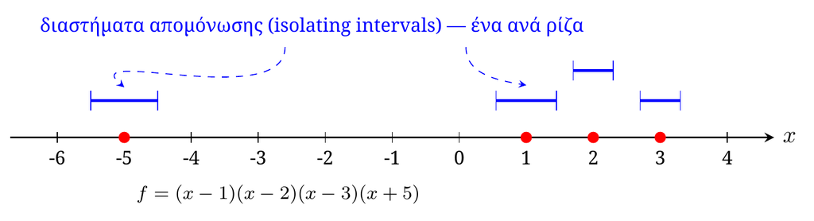

```
4-element Vector{Tuple{QQFieldElem, QQFieldElem}}:
 (-50, 0)
 (0, 25//16)
 (25//16, 75//32)
 (75//32, 25//8)
```

# Συνεχή κλάσματα

## Ο αλγόριθμος cf

Ο αλγόριθμος **cf** (Vincent 1836, Uspensky, Akritas) απομονώνει ρίζες σε “χώρο συνεχών κλασμάτων” αντί να διχοτομεί κυριολεκτικά ένα διάστημα.

**Σημείωση**

Αναγωγήματα $P_n/Q_n$ ενός συνεχούς κλάσματος $[a_0;a_1,\dots]$:
$$P_{n+1}=a_{n+1}P_n{+}P_{n-1}, \qquad Q_{n+1}=a_{n+1}Q_n{+}Q_{n-1}.$$

## Θεώρημα (Vincent, 1836)

Έστω $A$ τετραγωνο-ελεύθερο, βαθμού $d$, φράγμα διαχωρισμού $\sigma$. Υπάρχει $n$ (φραγμένο συναρτήσει $d,\sigma$) ώστε, για **κάθε** ακολουθία θετικών ακεραίων $a_0,\dots,a_n$, ο μετασχηματισμός
$$X \longmapsto [a_0;a_1,\dots,a_n,X] = \frac{P_nX+P_{n-1}}{Q_nX+Q_{n-1}}$$
μετατρέπει το $A$ σε πολυώνυμο με **το πολύ μία** εναλλαγή προσήμου.

## Ο αλγόριθμος

Διατηρούμε $M(X)=\dfrac{pX+q}{rX+s}$ και το $\hat A=A\circ M$ (αριθμητής, χωρίς παρονομαστές). Μετράμε τις εναλλαγές προσήμου $V$ του $\hat A$:

- $V=0$: καμία ρίζα — σταματάμε
- $V=1$: **μία** ρίζα (Vincent) — άκρα $M(0),M(\infty)$
- $V\ge2$: διακλάδωση σε $(1,\infty)$ ($X\mapsto X+1$) και $(0,1)$ ($X\mapsto 1/(1+X)$)

```
2-element Vector{Tuple{QQFieldElem, QQFieldElem}}:
 (-50, 0)
 (2, 50)
```

## Πολυπλοκότητα

Με κατάλληλη υλοποίηση [@tsigaridas2006phd, Θεώρ. 3.46–3.47]: $O(d^2+d\sigma)$ βήματα — **ίδια τάξη** με την υποδιαίρεση.

# Φράγμα διαχωρισμού

## Πόσο βαθιά χρειάζεται να διχοτομήσουμε;

**Ορισμός (Φράγμα διαχωρισμού)**

$$\operatorname{sep}(f) = \min_{i\neq j} |\gamma_i-\gamma_j|.$$

**Θεώρημα (Mignotte)**

$$\operatorname{sep}(f) \;\ge\; \sqrt{\dfrac{8}{d^{d+2}}} \cdot \dfrac{1}{(1+\max_i|a_i|)^{d}},$$
και αυτό είναι **βέλτιστο**.

## Συνέπεια: φράγμα πολυπλοκότητας

$$L = \log(\operatorname{sep}(f)) \in O\!\left(d \log\left(\max_i|a_i|\right)\right)$$

Αυτό φράσσει το **βάθος** του δέντρου υποδιαίρεσης — άρα και την πολυπλοκότητα ολόκληρης της μεθόδου.

(“αφελή” άνω φράγματα συχνά πιο ήπια απ’ ό,τι θα φοβόμασταν a priori)